# Logboek_Ivar

Ivar

2024-05-06

# Introductie

Dit logboek is gemaakt voor een experiment om te meten of suiker en zout invloed hebben op de gasproductie van gist.

# Library en versie

R 4.4.0 dplyr 1.1.4 ggplot2 3.5.1 tidyr 1.3.1 zoo 1.8-12 pwr 1.3-0

Uitleg van de library’s dplyr en tidyr zijn library’s voor het muteren en opmaken van data. ggplot2 gebruik ik om nette plotjes te maken. De library zoo heb ik gebruikt voor het extrapoleren van data en pwr heb ik gebruikt voor de statistische toetsten.

```r
library("pwr") # powertests
library("ggplot2") # plotjes
library("dplyr") # data mutaties
library("tidyr") # data mutaties
library("zoo") # interpolatie
```

[output not shown]

Groepslogboek # Logboek 26-4-2024

## Motivatie

we hebben het magazijn bezocht wij om te kijken of ons experiment mogelijk is op school en voor eventueel advies van de chemische/medische/biologische tak van ons instituut te krijgen.

## Wat hebben we gedaan

Magazijn bezoek

We hebben het magazijn op het ILST bezocht om te vragen over de mogelijkheden bij ons experiment. Tijden dit gesprek werd ons geadviseerd vanwege de gasdruk die vrij komt en de beschikbare middelen die er zijn om een maatbeker met een waterslot constructie te gebruiken in plaats van een losse spuit om de gasdruk te meten.

Verder hebben we via e-mail contact opgezocht met Folkert Fabel en Gert Hofstede voor verdere mogelijkheden.

## Resultaat en interpretatie

Op basis van het advies hebben wij ons protocol aangepast.

contact opgezocht met de 2 bovenstaande docenten om de vervolg stappen te bepalen. hier is nog geen reactie op gekomen.

# Logboek 6-5-2024

## Motivatie

Voor onderzoek powertest heb ik gedaan om een beetje inzicht te krijgen in het statischtisch bewijzen van een onderzoek.

## Wat heb ik gedaan

Voor onderzoek powertest https://wikistatistiek.amc.nl/Poweranalyse

### note to self:in de les statestiek

95% betrouwbaarheids interval met de powertest invoeren in het logboek. mischien via de Rnorm een theoretische dataset opbouwen met of een geschaalde suiker naar co2 data met of het vorige onderzoek (https://www.sciencedirect.com/science/article/pii/S2221169117309802#:~:text=3.-,Results,solution)%20(Figure%201).) of een rekenmethode van 1 van mijn colega’s om te bepalen wat we nodig hebben.

## Resutaat en interpetatie

na de statestiek les van woensdag 8-5-2024 een theoretische opzet maken om te bepalen wat de minimale hoeveelheid tests zijn.

#logboek 7-5-2024

## Motivatie

Concretere antwoorden krijgen over wat wij mogen lenen voor ons experiment [magazijn boezoek]. Dit heb ik gedaan omdat het onduidelijk is Aangeven waar wij staan in ons project en de moeilijkheden waar wij tegen aanlopen i.v.m. matriaal [gesprek ronald]. dit is als tussen gesprek met de docent.

## Wat heb ik gedaan

2de bezoek magazijn en gesprek ronald In het gesprek met ronald hebben wij over de situatie rondom ons matriaal besproken hieruit zijn een aantal optie’s naar voren gekomen waaronder potentieële locatie of het fermolab of d1.08. ook hebben we eventuele alternatieve opzetten besproken. Er is ook ter sprake gekomen om het hoeveelheid testen van 5(keer 2 want duplo keer 2 want 2 factoren) variable metingen te verlagen naar 3 om het experiment praktisch uitvoerbaarder te maken omdat 2*10 sample’s te veel opzet werk is

In het bezoek naar het magazijn hebben om duidelijkheid gevraagd over wat wij mogen lenen voor ons experiment. hieruit is gebleken vanwege het voormaat van het waterbad en het feit dat er geen doppen met slang zijn voor de elymer dat we daar een vervanging voor moeten regelen

## Resultaat en interpetatie

Vervanger regelen voor elemyer. toestemming gekregen voor het lenen van een waterbad toestemming van gekregen van peter voor het eventueel opzetten van ons experiment in het klaslokaal mits er voorzorgmaatregelen worden getroffen. mail-adres magazijn(MagazijnILST@org.hanze.nl) voor het opstellen van een verzoek mail voor waneer de datum bekent is op welke datum wij het experiment willen uitvoeren.

#logboek 8-5-2024

## Motivatie

Overleg met michiel was voor het voortgangs gesprek en samen met de docenten van de labzalen overlegt om te vragen of wij ook 1 van hun ruimtes mogen gebruiken.

## Wat heb ik gedaan

Na overleg met michiel over de mogenlijkheden van het experiment is er ter sprake gekomen dat we een leeg lablokaal kunnen gebruiken. naar overleg met michiel en docenten van het biologisch onderzoeks team lijkt het mogenlijk dat we een regelmatig lege labzaal kunnen gebruiken(H0.99), zoek hier voor contact met het magazijn.

##refereren onderzoek Voor de opzet data heb de suikerwaardes van een eerder onderzoek gebruikt en de zout waardes heb ik verzonnen vanwege een gebrek aan referentie punten. uit de verwachting vanuit de litratuur ben ik er van uitgegaan dat deze waardes lager zijn dan die van suiker

om deze data te gebruiken R code introduceren en uitlgeggen

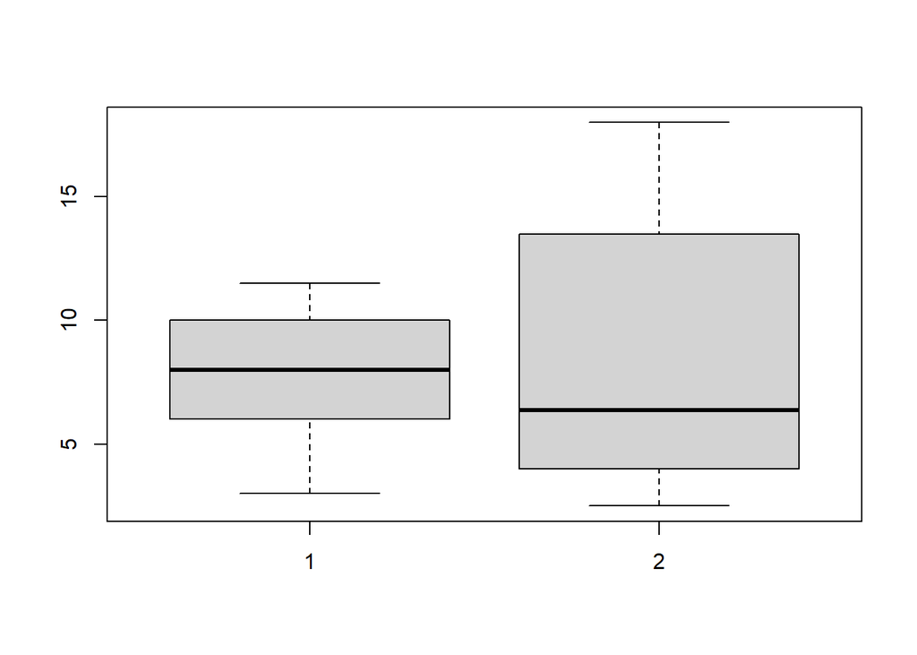

```r
test_suiker <- read.csv("../analysis/data/data_gist_testsheet_suiker.csv")
test_zout <- read.csv("../analysis/data/data_gist_testsheet_zout.csv")
#head(test_suiker)
#head(test_zout)
boxplot(test_suiker$productie_co2 , test_zout$productie_co2)
```

## Resultaat en interpetatie

2 potentiële experiment locatie’s H0.99 [vragen aan labmagazijn] en het masterlokaal

# logboek week 2 en 3

## Motivatie Ik heb op basis van de test dataset een fictieve statischtische analyse gemaakt om inzicht te krijgen over hoe onze analyse eruit zou kunnen zien.

## Wat heb ik gedaan Poweranalyse en T-tests

Nul hypothese test voor de nul hypothese test heb ik bijde colommen bij elkaar gevoegd met de reden dat de null hyptosese is Suiker en zout hebben geen invloed op de groei.

`r #suiker gem_output_s <- mean(test_suiker$productie_co2) deviatie_s <- sd(test_suiker$productie_co2) sample_count_s <- length(test_suiker$productie_co2) hist(test_suiker$productie_co2) curve(dnorm(x, mean = gem_output_s, sd = deviatie_s)*max(test_suiker$productie_co2), add = T)`

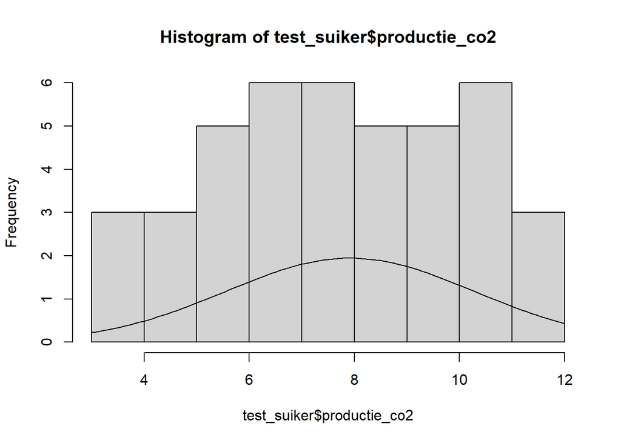

`r #zout gem_output_z <- mean(test_zout$productie_co2) deviatie_z <- sd(test_zout$productie_co2) sample_count_z <- length(test_zout$productie_co2) hist(test_zout$productie_co2) curve(dnorm(x,mean = gem_output_z, sd = deviatie_z)*max(test_zout$productie_co2), add = T)`

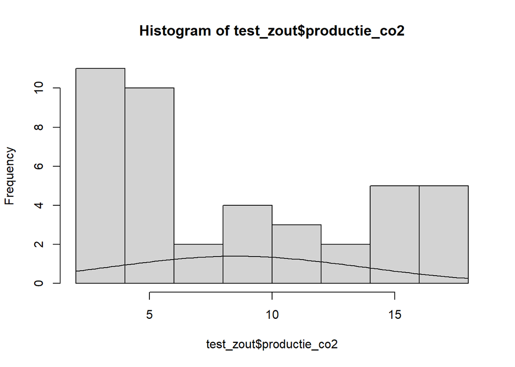

Betrouwbaarheids interval

`r # suiker BI_S <- gem_output_s + qt(c(0.025, 0.975),sample_count_s-1)* deviatie_s/sqrt(sample_count_s) # zout BI_Z <- gem_output_z + qt(c(0.025, 0.975),sample_count_z-1)* deviatie_z/sqrt(sample_count_z) cat(BI_S,"betrouwbaarheids interval suiker ",BI_Z,"Betrouwbaarheids interval zout")`

`## 7.181876 8.651458 betrouwbaarheids interval suiker 6.919101 10.12852 Betrouwbaarheids interval zout`

`r # suiker t.test(test_suiker$productie_co2 , mu = 0, alternative = "two.sided")`

`## ## One Sample t-test ## ## data: test_suiker$productie_co2 ## t = 21.759, df = 41, p-value < 2.2e-16 ## alternative hypothesis: true mean is not equal to 0 ## 95 percent confidence interval: ## 7.181876 8.651458 ## sample estimates: ## mean of x ## 7.916667`

`r # zout t.test(test_zout$productie_co2 , mu = 0, alternative = "two.sided")`

`## ## One Sample t-test ## ## data: test_zout$productie_co2 ## t = 10.727, df = 41, p-value = 1.796e-13 ## alternative hypothesis: true mean is not equal to 0 ## 95 percent confidence interval: ## 6.919101 10.128518 ## sample estimates: ## mean of x ## 8.52381`

``` r # suiker fout_in_gem_s <- deviatie_s/sqrt(gem_output_s) # zout fout_in_gem_z <- deviatie_z/sqrt(gem_output_z)

cat(fout_in_gem_s,“dit is de fout in het gemmidelde bij suiker”,” “,fout_in_gem_z,”dit is de fout in het gemiddelde bij zout”) ```

`## 0.8380398 dit is de fout in het gemmidelde bij suiker 1.763807 dit is de fout in het gemiddelde bij zout`

`r #suiker t_waarde_s <- t.test(test_suiker$productie_co2 , mu = 6, alternative = "two.sided") t_s <- t_waarde_s$statisti d_s <- t_s / sqrt(sample_count_s) cat(d_s,"d waarde suiker")`

`## 0.8128507 d waarde suiker`

`r # zout t_waarde_z <- t.test(test_zout$productie_co2 , mu = 6, alternative = "two.sided") t_z <- t_waarde_z$statisti d_z <- t_z / sqrt(sample_count_z) cat(" ",d_z,"d waarde zout")`

`## 0.4901043 d waarde zout`

`r # suiker pwr.t.test(d= d_s, sig.level = 0.05,power = 0.8, type = "one.sample", alternative = "two.sided")`

`## ## One-sample t test power calculation ## ## n = 13.92124 ## d = 0.8128507 ## sig.level = 0.05 ## power = 0.8 ## alternative = two.sided`

`r # zout pwr.t.test(d= d_z, sig.level = 0.05,power = 0.8, type = "one.sample", alternative = "two.sided")`

`## ## One-sample t test power calculation ## ## n = 34.64586 ## d = 0.4901043 ## sig.level = 0.05 ## power = 0.8 ## alternative = two.sided`

# logboek 13-5 ,14-5 en 15-5

## Motivatie

opzetting van de huiswerk opdracht gemaakt om alvast een taakverdeling te maken.

##Wat heb ik gedaan

Journalclub heatmap opdracht op 13-5 hebben wij de opdracht gekregen om een geavanceerde statestiek plot te maken, onze eerste idieën waren heatmap en scatterplot met trendline’s. ons 2de ideëe werd afgekeurd omdat die plot te simpel is opzichzelf, een voorwaarde om dit type plot goed te keuren is door het interactief te maken. Uiteindelijk hebben we gekozen voor een heatmap

besproken heatmap opdracht op 14-5 hebben wij met ronald de heatmap plot besproken en daarom kwam kritiek dat wij door 2 variabelen op 1 as te plaatsen. oplossing hiervoor is een facit wrap

Testdata opzetten 14-5 en 15-5

## Resultaat en interpetatie

heatmap met facet wrap vastgezet als project voor de journalclub

[output not shown]

# Logboek 16-5

## Motivatie

ik heb een gesprek met emil aangevraagd vanwege onzekerheid over het analyseren van ons onderzoek.

## Wat heb ik gedaan

Gesprek met emil appol over de statestiek van ons experiment. hieruit is vooruitgekomen dat vanwege het combineren van 2 factoren namenlijk zout en suiker een 2 weg anova de correcte analyse is, maar omdat wij praktisch niet de schaal hebben om het experiment op deze manier correct uit te voeren gaan wij 2 keer een 1 weg anova analyse voor de bijde factoren.

## Resultaat en interpetatie

oplossing voor ons statestiek probleem in de vorm van het uitvoeren van 2 keer een 1 weg anova notitie voor onderzoeksverslag vermelden dat een 2 weg anove de corecte manier was maar vanwege gebrek aan schaal

# logboek 17-5

## Motivatie

De reden dat wij toch een waterbad hebben gebruikt om dichter bij de optimuum tempratuur van gist te zitten dan dat de tempratuur was op de labzaal zelf. de meet freqwentie in verandering is gedaan vanwege de explosieve gastproductie waarvan wij dachten dat het binnen 250 ml gas zou blijven er binnen een kwartier al 2 experimenten zo veel produceerden dat zij over onze originele meetcapiciteit zouden gaan binnen een kwartier. d 1 van deze experimenten bleek een lek te zijn bij inspectie.

## Wat hebben we gedaan

Opzetten en uitvoeren van het experiment. In het gesprek met ronald tijdens het opzetten de hoeveelheid gist veranderd van 2 naar 7. en daarna heb ik concentratie berekening gemaakt voor de experimenten. Van het lab hebben wij een waterbad ter beschikking gekregen en hebben dit op 30 graden ingesteld.

### Uitvoering

tijden het experiment ging de gistproductie bij bepaalde experiment zo snel dat we al direct besloten om de meetfreqwentie van 1 keer per uur naar 1 keer per kwartier veranderen, omdat anders onze maatcilinders te lang leeg staan of we te lang of vaag co2 productie gaan loggen. ook hebben wij zodra het een meetcilinder leeg was hebben wij dit genoteerd bij de meting en hebben dit als 250 ml genoteerd en de cilinder opnieuw gevuld

## Resultaten en interpetatie

de hoeveelheid gist veranderd van 2 naar 7 gram vanwege gemak in meting en sterkere co2 productie

concentratie berekening per experiment gemaakt in de exel file meetsheet experiment in het suiker en zout concentratie blad.

experiment meetfreqwentie veranderd van om de 60 minuten naar 15 minuten. uitslagen gelogt in het meetsheet excel file in teams.

#logboek 21-5

##motivatie Ik en arjan hebben in de excel file de co2 producite berekent. dit hebben wij gedaan om werkbare meetgegevens te produceren om te gebruiken voor de statestiek in R.

##wat heb gedaan Omreken van de meetwaardes in de meetcilinders naar co2 productie gedaan plus een cumelative colom hierbij gemaakt.

##resultaten en interpetatie bij de 2 excel sheets de co2 productie gedeeltelijk uitgewerkt NOTE: de onregelmadigheden in de data bespreken met michiel en emil

[output not shown]

#logboek data verwerking Datums: 22-5, 23-5, 24-5,27-5,28-5

##Motivatie

### Analyse bespreking

van te voren met emil besproken hoe wij om kunnen gaan met onze onbetrouwbare data die waarschijnlijk niet normaal verdeeld is. Dit heb ik gedaan omdat ik niet zeker wist hoe wij dit op een betrouwbare manier kunnen testen

### Data verwerking

tijdens het verwerken van de data heb ik met michiel besproken hoe ik de foutive data corigeer. Dit heb ik gedaan omdat ik niet zeker wist hoe ik de meetfouten moest oplossen

##Wat heb ik gedaan

### Analyse bespreking

Ik heb met emil besproken over hoe ik de data betrouwbaar analyseer, Omdat onze data niet normaal verdeeld is werd geadviseerd de niet-parametrische toets de kruskal walles uit te voeren of log(y) te gebruiken bij de 1 weg anova

### Data verwerking

Samen met michiel een oplossing gevonden voor het extrapoleren doormiddel van de ZOO library die linaire interpolatie doet

##Code boek Exp.ID = Experiment ID [S= Suiker, Z = Zout, d = duplo] Meeting.nmr = meting nummer op volgorde prdc = co2 productie in ml/co2 Groep = Experiment origineel en duplo samen [E= experiment, s = suiker,z = zout, getal = experiment groep

## Analyses

### gemiddelden Ik bestudeer hier de gemidelden omdat ik inzicht wil krijgen in het verschil tussen het orginele experiment en het duplo experiment.

#### Suiker hieronder staan de gemiddelde productie waardes per experiment suiker, hieruit is af te lezen dat er een enorm verschil is in het orginele experiment en het duplo experiment. Er is wel een opbouwende trend te zien in hoe hoger de suikerconcentratie hoe hoger de productie.

`r (suiker_mean_data <- suiker_data %>% group_by(Exp.ID) %>% summarise(mean_s = mean(prdc)))`

`## # A tibble: 6 × 2 ## Exp.ID mean_s ## <chr> <dbl> ## 1 S1 0 ## 2 S2 0.273 ## 3 S3 7.45 ## 4 Sd1 -0.909 ## 5 Sd2 41.5 ## 6 Sd3 92.3` #### Zout Hieronder staan de gemiddelde prodictie waardes per experiment zout, hieruit kun je aflezen dat her verschil in experiment en duplo experiment er iets beter uitziet dan die van suiker. Maar nog steeds is hier stevig verschil tussen orgineel en duplo. De trend hier is de 2de concentratie de hoogste is en de andere 2 experimenten eronder vallen. dit kan duiden op een optimuum concentratie maar dat kan niet met zekerheid gezecht worden.

`r (zout_mean_data <- zout_data %>% group_by(Exp.ID) %>% summarise(mean_z = mean(prdc)))`

`## # A tibble: 6 × 2 ## Exp.ID mean_z ## <chr> <dbl> ## 1 Z1 56.7 ## 2 Z2 70.6 ## 3 Z3 13.7 ## 4 Zd1 29.6 ## 5 Zd2 47.2 ## 6 Zd3 30.9`

### histogrammen Deze histogrammen heb ik gemaakt om te kijken of onze data een normaal verdeling heeft.

#### Suiker Hieronder staat de histogram, hieruit kun je opmaken dat onze data niet normaal verdeeld is bij suiker.

`r hist(suiker_data$prdc, breaks = 10)`

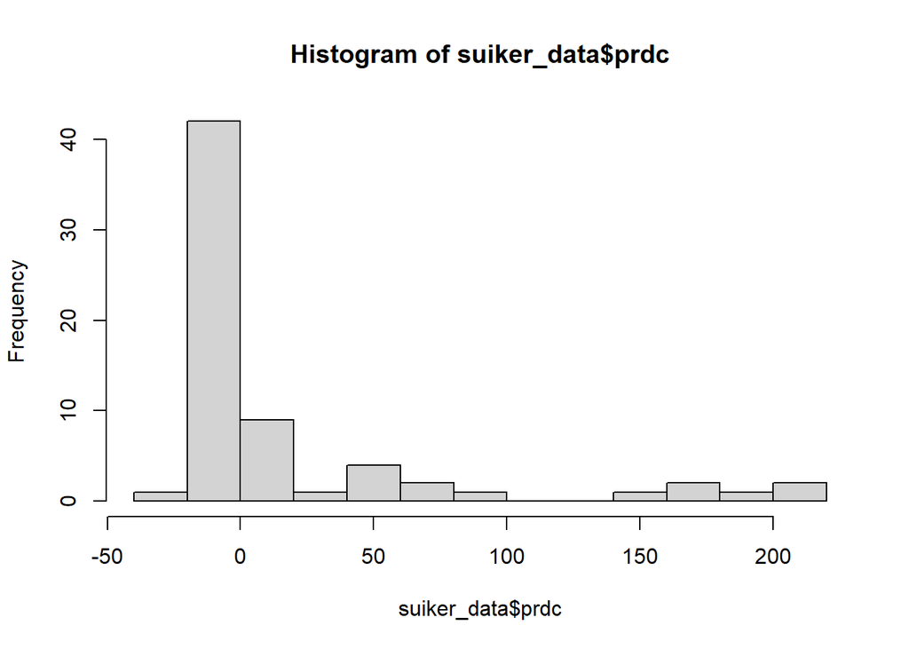

#### Zout Ook bij zout kun je zien dat de data niet normaal verdeeld is.

`r hist(zout_data$prdc, breaks = 10)`

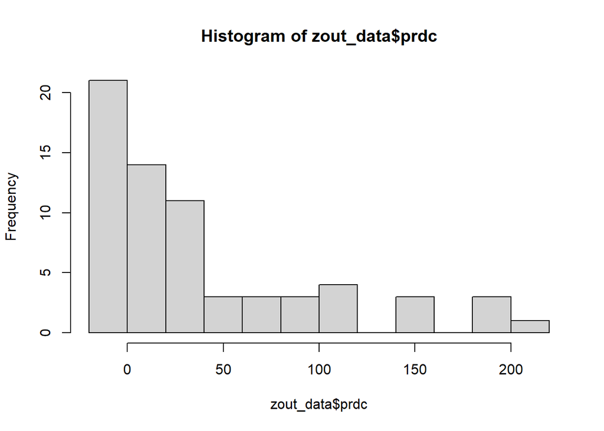

### Anova/Kruskal walles pipeline In dit blok is gemaakt voor de statische analyse van ons experiment. ik heb ervoor gekozen om zowel de 1 weg anova analyse te doen in log als de kruskal wallis analyse. Ik heb hiervoor gekozen omdat onze data niet normaal verdeeld is kunnen wij niet via de standaard statestiek toetsen kunnen toepassen.

#### Anova Bij de Anova toets liepen wij tegen 2 problemen aan. Het eerste probleem is dat we eigenlijk voor onze onderzoeksvraag we de 2-weg anova wilden toepassen omdat wij 2 factoren hebben die ik wil analyseren, maar dit bleek niet mogenlijke vanwege onze opzet. De opzet die wij nodig hadden voor een 2 weg anova is een 3x3 opzet van de verschillende concentratie’s, tijdens de uitvoring hadden wij een 2x3 opzet van de concentratie’s. Achteraf kwamen wij erachter dat je ook een fractal [design] 2 weg anova kunt doen met 5 data punten. maar wij hebben ervoor gekozen om het experiment niet opnieuw te doen vanwege het tijdsgebrek hebben wij dit niet gedaan

Hierdoor moeten wij 2 keer de 1 weg anova uitvoeren omdat wij 3 groepen hebben per factor. Dit heeft als resulaat dat wij wel conclussie’s kunnen trekken over of de factoren opzichzelf invloed hebben op de onderszoekvraag, maar we kunnen niet de factoren onderling ook nog invloed hebben.

het tweede probleem dat wij onregelmatige data hebben en hierdoor niet de standaard anova toe kunnen passen omdat deze er van uit gaat dat de data normaal verdeeld is. omdat dit niet het geval is gebruiken we de log() van de data. Dit is volgens emil de manier om niet normaal verdeelde data te corigeren voor de anova.

#### Kruskal Wallis De Kruskal Wallis toets voer ik uit omdat het een niet parametische toets is die mischien betrouwbaarder is op onze onbetrouwbare data dan de anova. in principe moet volgens emil hieruit ongeveer dezelfde resultaten uitkomen als de gecorigeerde anova.

#### Samenvoeging duplo experimenten Hier voeg ik de orginele experimenten samen met de duplo versie hiervan. dit doe ik als voorbereiding van de anova en kruskal test. Omdat duplo en orgineel als 1 experiment moet worden gezien.

`r suiker_data <- suiker_data %>% mutate(groep = case_match(Exp.ID, c("S1","Sd1") ~ "Es1", c("S2","Sd2") ~ "Es2", c("S3","Sd3") ~ "Es3")) head(suiker_data)`

`## Exp.ID Meeting.nmr prdc groep ## 1 S1 1 0 Es1 ## 2 S1 2 0 Es1 ## 3 S1 3 0 Es1 ## 4 S1 4 -2 Es1 ## 5 S1 5 0 Es1 ## 6 S1 6 2 Es1`

Hetzelfde als suiker